# Reproduction_Vijayan

Xin Wang and Sarah Bardin

## Data preprocessing

We first read in the raw dataset, which was obtained from the original authors of the paper. We rename the variables to more meaningful names and calculate three variables needed for analysis. We then restrict the data set to the analysis sample per the description provided in the original paper. Specifically, we filter to observations with non-missing COVID data (non-missing testing data and non-missing rate data) and with populations of at least 1000 people. We then further restrict to hexagons with contiguous neighbors.

```r
#-- Read in data file --#
ds_orig <- read_sf(here("data", "raw", "private", "LAhex_ACS_MOVED_703_UTM11N.shp"))

#-- Filter to analysis sample --#
ds_restricted <- ds_orig %>%
                        filter(DP05_0001E >= 1000 & !is.na(tested630_) & !is.na(crt630_mea)) %>%
                        rename(age18     = DP05_0019P,
                               age65     = DP05_0024P,
                               latino    = DP05_0071P,
                               white     = DP05_0037P,
                               black     = DP05_0038P,
                               asian     = DP05_0044P,
                               poverty   = DP03_0119P,
                               uninsured = DP03_0099P,
                               bachelor  = DP02_0067P,
                               pop.tot   = DP05_0001E,
                               hh_tot    = DP05_0086E,
                               tests     = tested630_,
                               cases     = cases630_s,
                               fid       = fid,
                               area      = areasqkm,
                               adjdrt    = adjdrt630_,
                               adjtrt    = adjtrt630_,
                               westside  = Westside) %>%
                        mutate(pop.dens  = pop.tot/10,      # calculate population density
                               hh.dens   = pop.tot/hh_tot,  # calculate household density
                               prt       = 100*cases/tests, # calculate crude positivity rates
                               prt_level = 0)               # create variable to fill with values later

QN <- poly2nb(ds_restricted, queen = T) # queen neighbors for each polygon
cards <- card(QN) # number of neighbors for each hexagon
no.neighbor.id <- which(cards == 0) # row id for hexagons containing 0 neighbors
ds_analysis <- ds_restricted[-no.neighbor.id,]
```

## Descriptive characteristics of the data

### Correlates of test positivity

To reproduce summary statistics from Table 1 of original analysis, we first need to create a categorical variable based on the continuous positivity rate (prt). The variable prt_level divides observations into 3 mutually exclusive categories (< 5%, 5% < 10%, and 10% or greater). We then take the mean and standard deviation of key covariates to reproduce Table 1. We also performed one-way ANOVA tests to assess for differences in mean values across subgroups. Vijayan et al. noted in-text that they performed “correlational analysis” but based on the presentation of the findings, it appeared that either ANOVA or Kruskal-Wallis tests were used to assess differences across the 3 subgroups. Given that we were able to identically reproduce the reported p-value for the only non-significant result using ANOVA, we suspect that ANOVA was performed for all variables regardless of the underlying distribution.

```r
# divide hexagons into 3 groups according to the positivity rate
for (i in 1:nrow(ds_analysis)) {
  if (ds_analysis$prt[i] < 5) ds_analysis$prt_level[i] <- "Low"
  if (ds_analysis$prt[i] >= 5 & ds_analysis$prt[i] < 10) ds_analysis$prt_level[i] <- "Med"
  if (ds_analysis$prt[i] >= 10) ds_analysis$prt_level[i] <- "High"
}
table(ds_analysis$prt_level)
```

```
##
## High  Low  Med
##   66   44   74
```

```r
# generate the descriptive statistics of the independent variables
data.sum <- ds_analysis %>%
  group_by(factor(prt_level)) %>%
  summarise(no.hex = length(prt_level),
            age18 = paste0(round(mean(age18, na.rm = T),1)," ","(",round(sd(age18, na.rm = T),2),")"),
            age65 = paste0(round(mean(age65, na.rm = T),1)," ","(",round(sd(age65, na.rm = T),2),")"),
            white = paste0(round(mean(white, na.rm = T),1)," ","(",round(sd(white, na.rm = T),2),")"),
            black = paste0(round(mean(black, na.rm = T),1)," ","(",round(sd(black, na.rm = T),2),")"),
            asian = paste0(round(mean(asian, na.rm = T),1)," ","(",round(sd(asian, na.rm = T),2),")"),
            latino = paste0(round(mean(latino, na.rm = T),1)," ","(",round(sd(latino, na.rm = T),2),")" ),
            poverty = paste0(round(mean(poverty, na.rm = T),1)," ","(",round(sd(poverty, na.rm = T),2),")" ),
            uninsured = paste0(round(mean(uninsured, na.rm = T),1)," ","(",round(sd(uninsured, na.rm = T),2),")"),
            bachelor = paste0(round(mean(bachelor, na.rm = T),1)," ","(",round(sd(bachelor, na.rm = T),2),")"),
            pop.dens = paste0(round(mean(pop.dens, na.rm = T),1)," ","(",round(sd(pop.dens, na.rm = T),2),")"),
            hh.dens = paste0(round(mean(hh.dens, na.rm = T),1)," ","(",round(sd(hh.dens, na.rm = T),2),")"))
#----------------------------------------------------------------------#
#-- Compute the analysis of variance (ANOVA) and post-hoc Tukey test --#
#----------------------------------------------------------------------#

#- Create function to perform ANOVA, post-hoc tukey test, and checks for normality and homoscedasticity -#

anova_test <- function (p)  {
  count = 1   ## create counter

  #-- Create empty lists to hold needed elements in return list --#
  pval <- list()
  hov <- list()
  norm_test <- list()
  krusk_pval <- list()

  #-- Loop over each of the predictors, perform ANOVA, extract p-values --#
  for (p in predictors) {

    print(paste("--------- RUNNING ANOVA FOR", quo_name(p), "-------------"))

    res.aov <- aov(as.formula(paste(p, "~", "prt_level")), data = ds_analysis)
    pval[[count]] <-  summary(res.aov)[[1]][1,5] ## store p-value from ANOVA to add to Table 1
    print(TukeyHSD(res.aov))  ## look at post-hoc Tukey test results

    #--Identify variables that fail ANOVA assumptions
    hov[[count]] <- leveneTest(as.formula(paste(p, "~", "prt_level")), data = ds_analysis)$"Pr(>F)"[1]  ## assess homogeneity of variances
    norm_test[[count]] <- shapiro.test(x = residuals(object = res.aov))$p.value  ## assess normality assumption


    print(paste("--------- RUNNING KRUSKAL-WALLIS FOR", quo_name(p), "-------------"))
    res.krusk <- kruskal.test(as.formula(paste(p, "~", "prt_level")), data = ds_analysis)
    krusk_pval[[count]] <-  res.krusk$p.value ## store p-value from ANOVA to add to Table 1


    #--Create list of ANOVA results for reporting purposes
    aov_results <- (list("pvalue" = pval, "levene" = hov, "shapiro" = norm_test, "kruskal_pvalue" = krusk_pval))
    count = count + 1
  }

  return(aov_results)
}

#- Define list of predictors and run ANOVA function -#
predictors <- c("age18",
                "age65",
                "white",
                "black",
                "asian",
                "latino",
                "poverty",
                "uninsured",
                "bachelor",
                "pop.dens",
                "hh.dens")
aov_results <- anova_test(predictors)
```

```
## [1] "--------- RUNNING ANOVA FOR age18 -------------"
##   Tukey multiple comparisons of means
##     95% family-wise confidence level
##
## Fit: aov(formula = as.formula(paste(p, "~", "prt_level")), data = ds_analysis)
##
## $prt_level
##               diff        lwr       upr     p adj
## Low-High -5.745424 -7.6460514 -3.844796 0.0000000
## Med-High -4.619574 -6.2729636 -2.966184 0.0000000
## Med-Low   1.125850 -0.7332294  2.984929 0.3270995
```

```
## [1] "--------- RUNNING KRUSKAL-WALLIS FOR age18 -------------"
## [1] "--------- RUNNING ANOVA FOR age65 -------------"
##   Tukey multiple comparisons of means
##     95% family-wise confidence level
##
## Fit: aov(formula = as.formula(paste(p, "~", "prt_level")), data = ds_analysis)
##
## $prt_level
##               diff       lwr       upr    p adj
## Low-High  5.579277  3.553750 7.6048054 0.000000
## Med-High  3.946435  2.184393 5.7084777 0.000001
## Med-Low  -1.632842 -3.614091 0.3484064 0.128473
```

```
## [1] "--------- RUNNING KRUSKAL-WALLIS FOR age65 -------------"
## [1] "--------- RUNNING ANOVA FOR white -------------"
##   Tukey multiple comparisons of means
##     95% family-wise confidence level
##
## Fit: aov(formula = as.formula(paste(p, "~", "prt_level")), data = ds_analysis)
##
## $prt_level
##                diff        lwr       upr     p adj
## Low-High  21.901330  14.356435  29.44622 0.0000000
## Med-High   2.627512  -3.935925   9.19095 0.6119143
## Med-Low  -19.273817 -26.653777 -11.89386 0.0000000
```

```
## [1] "--------- RUNNING KRUSKAL-WALLIS FOR white -------------"
## [1] "--------- RUNNING ANOVA FOR black -------------"
##   Tukey multiple comparisons of means
##     95% family-wise confidence level
##
## Fit: aov(formula = as.formula(paste(p, "~", "prt_level")), data = ds_analysis)
##
## $prt_level
##                diff       lwr      upr     p adj
## Low-High -3.4833627 -8.918120 1.951395 0.2864423
## Med-High  0.1251273 -4.602664 4.852919 0.9978457
## Med-Low   3.6084900 -1.707460 8.924441 0.2465082
```

```
## [1] "--------- RUNNING KRUSKAL-WALLIS FOR black -------------"
## [1] "--------- RUNNING ANOVA FOR asian -------------"
##   Tukey multiple comparisons of means
##     95% family-wise confidence level
##
## Fit: aov(formula = as.formula(paste(p, "~", "prt_level")), data = ds_analysis)
##
## $prt_level
##               diff        lwr      upr     p adj
## Low-High  4.456893 -2.1187677 11.03255 0.2475318
## Med-High 10.114898  4.3946142 15.83518 0.0001344
## Med-Low   5.658005 -0.7739089 12.08992 0.0971035
```

```
## [1] "--------- RUNNING KRUSKAL-WALLIS FOR asian -------------"
## [1] "--------- RUNNING ANOVA FOR latino -------------"
##   Tukey multiple comparisons of means
##     95% family-wise confidence level
##
## Fit: aov(formula = as.formula(paste(p, "~", "prt_level")), data = ds_analysis)
##
## $prt_level
##               diff       lwr       upr p adj
## Low-High -52.07608 -60.14796 -44.00420     0
## Med-High -31.52947 -38.55134 -24.50760     0
## Med-Low   20.54661  12.65119  28.44204     0
```

```
## [1] "--------- RUNNING KRUSKAL-WALLIS FOR latino -------------"
## [1] "--------- RUNNING ANOVA FOR poverty -------------"
##   Tukey multiple comparisons of means
##     95% family-wise confidence level
##
## Fit: aov(formula = as.formula(paste(p, "~", "prt_level")), data = ds_analysis)
##
## $prt_level
##                diff        lwr       upr    p adj
## Low-High -11.675808 -14.347601 -9.004014 0.00e+00
## Med-High  -6.449369  -8.773609 -4.125128 0.00e+00
## Med-Low    5.226439   2.613052  7.839826 1.36e-05
```

```
## [1] "--------- RUNNING KRUSKAL-WALLIS FOR poverty -------------"
## [1] "--------- RUNNING ANOVA FOR uninsured -------------"
##   Tukey multiple comparisons of means
##     95% family-wise confidence level
##
## Fit: aov(formula = as.formula(paste(p, "~", "prt_level")), data = ds_analysis)
##
## $prt_level
##               diff        lwr       upr    p adj
## Low-High -8.229077 -10.058012 -6.400142 0.00e+00
## Med-High -4.755776  -6.346799 -3.164754 0.00e+00
## Med-Low   3.473301   1.684347  5.262254 2.48e-05
```

```
## [1] "--------- RUNNING KRUSKAL-WALLIS FOR uninsured -------------"
## [1] "--------- RUNNING ANOVA FOR bachelor -------------"
##   Tukey multiple comparisons of means
##     95% family-wise confidence level
##
## Fit: aov(formula = as.formula(paste(p, "~", "prt_level")), data = ds_analysis)
##
## $prt_level
##               diff       lwr       upr p adj
## Low-High  40.89949  34.72462  47.07435     0
## Med-High  17.93606  12.56443  23.30768     0
## Med-Low  -22.96343 -29.00331 -16.92355     0
```

```
## [1] "--------- RUNNING KRUSKAL-WALLIS FOR bachelor -------------"
## [1] "--------- RUNNING ANOVA FOR pop.dens -------------"
##   Tukey multiple comparisons of means
##     95% family-wise confidence level
##
## Fit: aov(formula = as.formula(paste(p, "~", "prt_level")), data = ds_analysis)
##
## $prt_level
##                diff          lwr        upr     p adj
## Low-High -2133.2841 -3028.614704 -1237.9535 0.0000002
## Med-High -1265.7827 -2044.646601  -486.9188 0.0004960
## Med-Low    867.5014    -8.256768  1743.2596 0.0528160
```

```
## [1] "--------- RUNNING KRUSKAL-WALLIS FOR pop.dens -------------"
## [1] "--------- RUNNING ANOVA FOR hh.dens -------------"
##   Tukey multiple comparisons of means
##     95% family-wise confidence level
##
## Fit: aov(formula = as.formula(paste(p, "~", "prt_level")), data = ds_analysis)
##
## $prt_level
##                diff        lwr        upr   p adj
## Low-High -1.1817932 -1.4194771 -0.9441092 0.0e+00
## Med-High -0.6990655 -0.9058310 -0.4923001 0.0e+00
## Med-Low   0.4827276  0.2502396  0.7152157 6.1e-06
```

```
## [1] "--------- RUNNING KRUSKAL-WALLIS FOR hh.dens -------------"
```

```r
# Extract p-values from each ANOVA and merge with descriptive statistics to construct Table 1
aov_pval <- as.data.frame(aov_results$pvalue)
aov_pval2 <- as.data.frame(t(aov_pval))
aov_pval2$row_num <- seq.int(nrow(aov_pval2))

table1_summary <- as.data.frame(t(data.sum))
table1_summary <- table1_summary %>%
                      mutate(row_num = seq.int(nrow(table1_summary)) - 2,
                             rowname = factor(colnames(data.sum)))

table1 <- left_join(table1_summary, aov_pval2, by = "row_num")

table1 <- table1 %>%
              filter(row_num<12 & row_num>=0) %>%
              transmute(Variable = rowname,
                        Low      = as.character(V2),
                        Med      = as.character(V3),
                        High     = as.character(V1.x),
                        pval     = round(V1.y,3))

write.csv(table1, here("results", "other", "Table1_summarystats.csv"))

#--------------------------------------------------#
#--Identify variables that fail ANOVA assumptions--#
#--------------------------------------------------#

aov_levene <- as.data.frame(aov_results$levene)
aov_levene2 <- as.data.frame(t(aov_levene))
aov_levene2$row_num <- seq.int(nrow(aov_levene2))

aov_shapiro <- as.data.frame(aov_results$shapiro)
aov_shapiro2 <- as.data.frame(t(aov_shapiro))
aov_shapiro2$row_num <- seq.int(nrow(aov_shapiro2))

aov_assumptions <- inner_join(aov_shapiro2, aov_levene2, by = "row_num")
aov_assumptions$failed = ifelse(aov_assumptions$V1.x<0.05 | aov_assumptions$V1.y <0.05,1,0)
which(aov_assumptions$failed==1) ## all variables except for age18 and hh.dens fail ANOVA assumptions
```

```
## [1]  2  3  4  5  6  7  8  9 10
```

```r
aov_krusk<- as.data.frame(aov_results$kruskal_pvalue)
aov_krusk2 <- as.data.frame(t(aov_krusk))
aov_krusk2$row_num <- seq.int(nrow(aov_krusk2))
which(aov_krusk2$V1>=0.05) ## only black is not statistically significant using kruskal wallis test
```

```
## [1] 4
```

## LISA

LISA analyses for the adjusted testing rate, adjusted diagnosis rate, and crude positivity rate were performed, using a queens weighting matrix. Although in the original analysis, only high-high and low-low clusters were mapped, for completeness we develop maps showing all statistically significant clusters based on a permutation approach. The original authors did not specify the number of simulations performed in their analysis, so we have left the default number (N= 499) for the purposes of our reproductions.

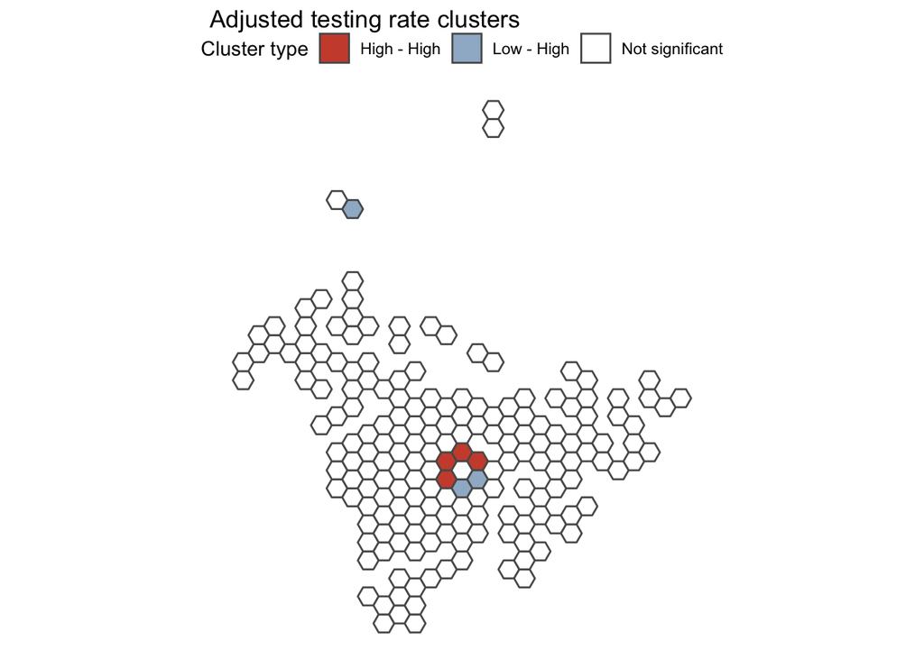

```r
#-- Create spatial weights matrix --#
QN <- poly2nb(ds_analysis, queen = T)
QN1.lw <- nb2listw(QN, style = "B")
W  <- as(QN1.lw, "symmetricMatrix")
W <- as.matrix(W/rowSums(W)) ## row standardize
W[which(is.na(W))] <- 0 ## assign NA to zero

#-- set breaks to critical z values --#
breaks <- c(-100, -2.58, -1.96, -1.65, 1.65, 1.96, 2.58, 100)

#-----------------------------------------#
#- Perform LISA on Adjusted Testing Rate -#
#-----------------------------------------#

I.test <- localmoran_perm(ds_analysis$adjtrt, QN1.lw, nsim=499)
ds_analysis$test.I.zscore <- I.test[,4]

# findInterval() assigns ranks to the zvalues based on which bin the z values would fall into
# where the bins are broken up by the "breaks" variable created above
ds_analysis$test.I.zscore <- findInterval(ds_analysis$test.I.zscore, breaks, all.inside = TRUE)

test.z <- scale(ds_analysis$adjtrt)[,1]
patterns <- as.character(interaction(test.z > 0, W%*%test.z > 0))
patterns <- patterns %>%
  str_replace_all("TRUE","High") %>%
  str_replace_all("FALSE","Low")

patterns[ds_analysis$test.I.zscore  == 4] <- "Not significant"
ds_analysis$test.pattern <- patterns

ds_analysis$test.pattern2 <- factor(ds_analysis$test.pattern,
                              levels=c("High.High", "High.Low", "Low.High", "Low.Low", "Not significant"),
                              labels=c("High - High", "High - Low", "Low - High",
                                       "Low - Low", "Not significant"))

test <- ggplot() +
  geom_sf(data=ds_analysis, aes(fill=test.pattern2)) +
  theme_void() +
  scale_fill_manual(values = c("tomato3", "slategray3", "white")) +
  guides(fill = guide_legend(title="Cluster type")) +
  labs(title="Adjusted testing rate clusters")  +
  theme(legend.position = "top")
test
```

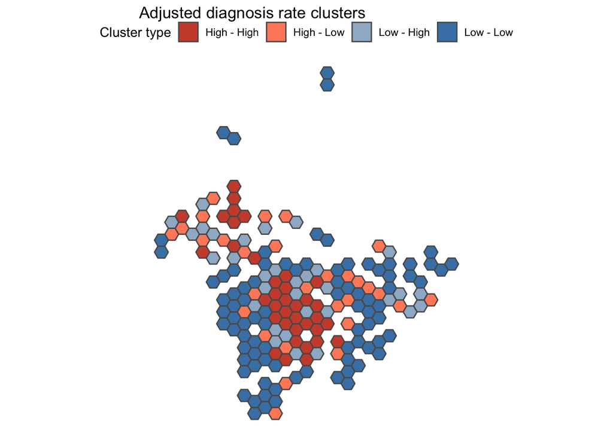

```r
#---------------------------------------------#
#-- Perform LISA on Adjusted Diagnosis Rate --#
#---------------------------------------------#

I.test <- localmoran_perm(ds_analysis$adjdrt, QN1.lw, nsim=499)
ds_analysis$diag.I.zscore <- I.test[,4]

# findInterval() assigns ranks to the zvalues based on which bin the z values would fall into
# where the bins are broken up by the "breaks" variable created above
ds_analysis$daig.I.zscore <- findInterval(ds_analysis$diag.I.zscore, breaks, all.inside = TRUE)

diag.z <- scale(ds_analysis$adjdrt)[,1]
patterns <- as.character(interaction(diag.z > 0, W%*%diag.z > 0))
patterns <- patterns %>%
  str_replace_all("TRUE","High") %>%
  str_replace_all("FALSE","Low")

patterns[ds_analysis$diag.I.zscore  == 4] <- "Not significant"
ds_analysis$diag.pattern <- patterns

ds_analysis$diag.pattern2 <- factor(ds_analysis$diag.pattern,
                              levels=c("High.High", "High.Low", "Low.High", "Low.Low", "Not significant"),
                              labels=c("High - High", "High - Low", "Low - High",
                                       "Low - Low", "Not significant"))

diag <- ggplot() +
  geom_sf(data=ds_analysis, aes(fill=diag.pattern2)) +
  theme_void() +
  scale_fill_manual(values = c("tomato3", "salmon1", "slategray3", "steelblue", "white")) +
  guides(fill = guide_legend(title="Cluster type")) +
  labs(title="Adjusted diagnosis rate clusters")  +
  theme(legend.position = "top")
diag
```

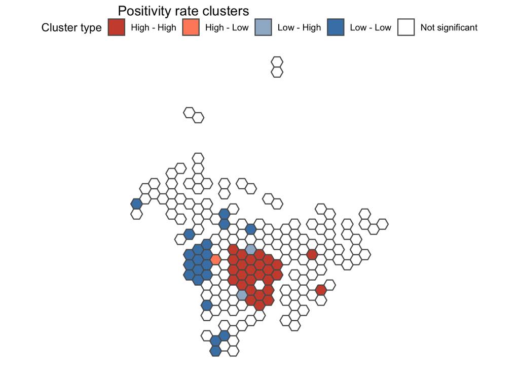

```r
#-----------------------------------#
#- Perform LISA on Positivity Rate -#
#-----------------------------------#
I.test <- localmoran_perm(ds_analysis$prt, QN1.lw, nsim=499)
ds_analysis$pos.I.zscore <- I.test[,4]

# findInterval() assigns ranks to the zvalues based on which bin the z values would fall into
# where the bins are broken up by the "breaks" variable created above
ds_analysis$pos.I.zscore <- findInterval(ds_analysis$pos.I.zscore, breaks, all.inside = TRUE)

pos.z <- scale(ds_analysis$prt)[,1]
patterns <- as.character(interaction(pos.z > 0, W%*%pos.z > 0))
patterns <- patterns %>%
  str_replace_all("TRUE","High") %>%
  str_replace_all("FALSE","Low")

patterns[ds_analysis$pos.I.zscore  == 4] <- "Not significant"
ds_analysis$pos.pattern <- patterns

ds_analysis$pos.pattern2 <- factor(ds_analysis$pos.pattern,
                              levels=c("High.High", "High.Low", "Low.High", "Low.Low", "Not significant"),
                              labels=c("High - High", "High - Low", "Low - High",
                                       "Low - Low", "Not significant"))

pos <- ggplot() +
  geom_sf(data=ds_analysis, aes(fill=pos.pattern2)) +
  theme_void() +
  scale_fill_manual(values = c("tomato3", "salmon1", "slategray3", "steelblue", "white")) +
  guides(fill = guide_legend(title="Cluster type")) +
  labs(title="Positivity rate clusters")  +
  theme(legend.position = "top")
pos
```

## Spatially lagged models

### Main Results

Below we reproduce Table 2 of the original paper by running an SAR model where our dependent variable is the crude positivity rate and our independent variables include age, race, poverty, uninsurance, education, population density, and household density (which is really average household size)

```r
#-- Center the variables to a mean of 0 and scale to an sd of 1 --#
ds_analysis_centered <- ds_analysis %>%
  mutate_at(c("adjtrt", "adjdrt", "prt", "age18", "age65", "latino", "white",
              "black", "asian", "poverty", "uninsured", "bachelor", "pop.dens",
              "hh.dens"), ~(scale(.) %>% as.vector))

#---------------------------------------------#
#-- Perform SAR on Crude Positivity Rate --#
#---------------------------------------------#

#-- Define the regression equation --#
reg.eq1 <- prt ~ age18 + age65 + latino + white + black + asian +  poverty +
                 uninsured + bachelor + pop.dens + hh.dens -1

SReg.SAR1 = lagsarlm(reg.eq1, data = ds_analysis_centered, QN1.lw)

#-- get the total, indirect, and direct effects --#
summary(SReg.SAR1)
```

```
##
## Call:lagsarlm(formula = reg.eq1, data = ds_analysis_centered, listw = QN1.lw)
##
## Residuals:
##       Min        1Q    Median        3Q       Max
## -2.304782 -0.335076 -0.040674  0.246371  2.607621
##
## Type: lag
## Coefficients: (asymptotic standard errors)
##             Estimate Std. Error z value Pr(>|z|)
## age18     -0.0361096  0.0767293 -0.4706  0.63792
## age65      0.1775353  0.0705867  2.5151  0.01190
## latino     0.3101702  0.1633375  1.8990  0.05757
## white      0.0801547  0.1344270  0.5963  0.55100
## black      0.0296449  0.1067693  0.2777  0.78128
## asian     -0.0117678  0.1296232 -0.0908  0.92766
## poverty    0.1976834  0.1075030  1.8389  0.06594
## uninsured  0.0672479  0.1182981  0.5685  0.56972
## bachelor  -0.0090995  0.1346985 -0.0676  0.94614
## pop.dens   0.1506108  0.0716871  2.1009  0.03565
## hh.dens    0.2975872  0.1142082  2.6057  0.00917
##
## Rho: 0.045909, LR test value: 6.3582, p-value: 0.011684
## Asymptotic standard error: 0.017981
##     z-value: 2.5533, p-value: 0.010672
## Wald statistic: 6.5192, p-value: 0.010672
##
## Log likelihood: -157.4694 for lag model
## ML residual variance (sigma squared): 0.32164, (sigma: 0.56713)
## Number of observations: 184
## Number of parameters estimated: 13
## AIC: 340.94, (AIC for lm: 345.3)
## LM test for residual autocorrelation
## test value: 0.0052431, p-value: 0.94228
```

```r
summary(impacts(SReg.SAR1, listw = QN1.lw, R = 499), zstats = TRUE)
```

```
## Impact measures (lag, exact):
##                Direct     Indirect       Total
## age18     -0.03641050 -0.007279965 -0.04369046
## age65      0.17901453  0.035792408  0.21480694
## latino     0.31275462  0.062532584  0.37528720
## white      0.08082261  0.016159783  0.09698239
## black      0.02989193  0.005976633  0.03586856
## asian     -0.01186589 -0.002372481 -0.01423837
## poverty    0.19933052  0.039854414  0.23918493
## uninsured  0.06780825  0.013557673  0.08136592
## bachelor  -0.00917527 -0.001834516 -0.01100979
## pop.dens   0.15186571  0.030364236  0.18222994
## hh.dens    0.30006673  0.059995750  0.36006248
## ========================================================
## Simulation results (asymptotic variance matrix):
## Direct:
##
## Iterations = 1:499
## Thinning interval = 1
## Number of chains = 1
## Sample size per chain = 499
##
## 1. Empirical mean and standard deviation for each variable,
##    plus standard error of the mean:
##
##                Mean      SD Naive SE Time-series SE
## age18     -0.035211 0.07802 0.003493       0.003108
## age65      0.177234 0.07188 0.003218       0.003218
## latino     0.306061 0.15999 0.007162       0.007563
## white      0.083224 0.13118 0.005872       0.005872
## black      0.031753 0.10319 0.004620       0.005961
## asian     -0.010586 0.12508 0.005599       0.005599
## poverty    0.203942 0.11089 0.004964       0.005755
## uninsured  0.072068 0.12236 0.005478       0.005478
## bachelor  -0.006857 0.12986 0.005814       0.005814
## pop.dens   0.149408 0.07191 0.003219       0.003219
## hh.dens    0.303287 0.11186 0.005008       0.004665
##
## 2. Quantiles for each variable:
##
```

[output cut: 118 more lines]

```
## hh.dens    2.71120847  1.68389752  2.72739198
##
## Simulated p-values:
##           Direct    Indirect Total
## age18     0.6517680 0.713910 0.6577339
## age65     0.0136770 0.120947 0.0139462
## latino    0.0557418 0.193518 0.0606076
## white     0.5258056 0.587810 0.5303935
## black     0.7583110 0.797896 0.7626795
## asian     0.9325524 0.956565 0.9362968
## poverty   0.0658977 0.181441 0.0651317
## uninsured 0.5558707 0.620572 0.5604121
## bachelor  0.9578924 0.974213 0.9602508
## pop.dens  0.0377276 0.165375 0.0424033
## hh.dens   0.0067038 0.092201 0.0063837
```

### Supplemental Results

Below we reproduce the supplemental results from the original paper by running an SAR model where our dependent variable is the adjusted diagnosis rate and our independent variables include race, poverty, uninsurance, education, population density, and household density (which is really average household size). We repeat the same analysis using the adjusted testing rate as our dependent variable.

```r
#---------------------------------------------#
#-- Perform SAR on Adjusted Diagnosis Rate --#
#---------------------------------------------#

# Define the regression equation
reg.eq2 <- adjdrt ~ latino + white + black + asian + poverty + uninsured + bachelor + pop.dens + hh.dens - 1

SReg.SAR2 = lagsarlm(reg.eq2, data = ds_analysis_centered, QN1.lw)

#-- get the total, indirect, and direct effects --#
summary(SReg.SAR2)
```

```
##
## Call:lagsarlm(formula = reg.eq2, data = ds_analysis_centered, listw = QN1.lw)
##
## Residuals:
##      Min       1Q   Median       3Q      Max
## -1.04689 -0.41895 -0.12368  0.17622  7.88701
##
## Type: lag
## Coefficients: (asymptotic standard errors)
##            Estimate Std. Error z value Pr(>|z|)
## latino    -0.182054   0.255063 -0.7138  0.47537
## white     -0.042085   0.210620 -0.1998  0.84163
## black     -0.091811   0.166982 -0.5498  0.58244
## asian     -0.059698   0.197111 -0.3029  0.76199
## poverty   -0.028325   0.152575 -0.1856  0.85272
## uninsured  0.448124   0.183905  2.4367  0.01482
## bachelor   0.094647   0.208397  0.4542  0.64971
## pop.dens   0.204022   0.109553  1.8623  0.06256
## hh.dens    0.135152   0.140460  0.9622  0.33594
##
## Rho: -0.032619, LR test value: 1.6196, p-value: 0.20315
## Asymptotic standard error: 0.026383
##     z-value: -1.2364, p-value: 0.21633
## Wald statistic: 1.5286, p-value: 0.21633
##
## Log likelihood: -240.3907 for lag model
## ML residual variance (sigma squared): 0.79557, (sigma: 0.89195)
## Number of observations: 184
## Number of parameters estimated: 11
## AIC: 502.78, (AIC for lm: 502.4)
## LM test for residual autocorrelation
## test value: 4.4563, p-value: 0.034774
```

```r
summary(impacts(SReg.SAR2, listw = QN1.lw, R = 499), zstats = TRUE)
```

```
## Impact measures (lag, exact):
##                Direct     Indirect       Total
## latino    -0.18273192  0.019548295 -0.16318362
## white     -0.04224132  0.004518891 -0.03772242
## black     -0.09215311  0.009858355 -0.08229475
## asian     -0.05992066  0.006410192 -0.05351046
## poverty   -0.02843060  0.003041449 -0.02538915
## uninsured  0.44979290 -0.048117945  0.40167495
## bachelor   0.09499934 -0.010162840  0.08483650
## pop.dens   0.20478143 -0.021907108  0.18287433
## hh.dens    0.13565580 -0.014512187  0.12114362
## ========================================================
## Simulation results (asymptotic variance matrix):
## Direct:
##
## Iterations = 1:499
## Thinning interval = 1
## Number of chains = 1
## Sample size per chain = 499
##
## 1. Empirical mean and standard deviation for each variable,
##    plus standard error of the mean:
##
##               Mean     SD Naive SE Time-series SE
## latino    -0.18186 0.2478 0.011091       0.011091
## white     -0.04645 0.2147 0.009611       0.009611
## black     -0.09321 0.1721 0.007705       0.007705
## asian     -0.06160 0.2034 0.009103       0.009103
## poverty   -0.02879 0.1547 0.006925       0.006925
## uninsured  0.44054 0.1928 0.008631       0.008631
## bachelor   0.09200 0.2123 0.009505       0.010608
## pop.dens   0.20721 0.1131 0.005064       0.006201
## hh.dens    0.13762 0.1431 0.006405       0.005491
##
## 2. Quantiles for each variable:
##
##                 2.5%      25%      50%      75%  97.5%
## latino    -0.6580876 -0.34709 -0.18738 -0.01935 0.3438
## white     -0.4650609 -0.20332 -0.04684  0.09453 0.3686
## black     -0.4197620 -0.21300 -0.09527  0.02084 0.2441
```

[output cut: 98 more lines]

```
## bachelor   0.4332957 -0.33240337  0.4284209
## pop.dens   1.8315794 -0.83967131  1.8274510
## hh.dens    0.9619213 -0.57671954  0.9558249
##
## Simulated p-values:
##           Direct   Indirect Total
## latino    0.462941 0.62957  0.466553
## white     0.828717 0.85975  0.831015
## black     0.588117 0.71263  0.588049
## asian     0.761946 0.83011  0.761486
## poverty   0.852354 0.94690  0.844895
## uninsured 0.022323 0.33221  0.025271
## bachelor  0.664800 0.73958  0.668345
## pop.dens  0.067014 0.40109  0.067632
## hh.dens   0.336089 0.56413  0.339161
```

```r
#---------------------------------------------#
#-- Perform SAR on Adjusted Testing Rate --#
#---------------------------------------------#

# Define the regression equation
reg.eq3 <- adjtrt ~ latino + white + black + asian + poverty + uninsured + bachelor + pop.dens + hh.dens - 1

SReg.SAR3 = lagsarlm(reg.eq3, data = ds_analysis_centered, QN1.lw)

#-- get the total, indirect, and direct effects --#
summary(SReg.SAR3)
```

```
##
## Call:lagsarlm(formula = reg.eq3, data = ds_analysis_centered, listw = QN1.lw)
##
## Residuals:
##       Min        1Q    Median        3Q       Max
## -1.201502 -0.303870 -0.123014  0.071088  9.851303
##
## Type: lag
## Coefficients: (asymptotic standard errors)
##             Estimate Std. Error z value Pr(>|z|)
## latino    -0.0795664  0.2780195 -0.2862   0.7747
## white      0.0558879  0.2297381  0.2433   0.8078
## black     -0.0574893  0.1820426 -0.3158   0.7522
## asian     -0.1669026  0.2149209 -0.7766   0.4374
## poverty    0.1651352  0.1655837  0.9973   0.3186
## uninsured -0.1064317  0.2001498 -0.5318   0.5949
## bachelor  -0.0558531  0.2271250 -0.2459   0.8057
## pop.dens  -0.0502961  0.1189893 -0.4227   0.6725
## hh.dens    0.0025326  0.1532060  0.0165   0.9868
##
## Rho: 0.015669, LR test value: 0.28652, p-value: 0.59246
## Asymptotic standard error: 0.026433
##     z-value: 0.59281, p-value: 0.55331
## Wald statistic: 0.35142, p-value: 0.55331
##
## Log likelihood: -256.0945 for lag model
## ML residual variance (sigma squared): 0.94635, (sigma: 0.9728)
## Number of observations: 184
## Number of parameters estimated: 11
## AIC: 534.19, (AIC for lm: 532.48)
## LM test for residual autocorrelation
## test value: 0.11991, p-value: 0.72913
```

```r
summary(impacts(SReg.SAR3, listw = QN1.lw, R = 499), zstats = TRUE)
```

```
## Impact measures (lag, exact):
##                 Direct      Indirect        Total
## latino    -0.079639051 -0.0047915818 -0.084430633
## white      0.055938917  0.0033656340  0.059304551
## black     -0.057541783 -0.0034620724 -0.061003855
## asian     -0.167054966 -0.0100510683 -0.177106034
## poverty    0.165286005  0.0099446366  0.175230642
## uninsured -0.106528839 -0.0064094391 -0.112938278
## bachelor  -0.055904054 -0.0033635364 -0.059267590
## pop.dens  -0.050341979 -0.0030288873 -0.053370866
## hh.dens    0.002534924  0.0001525168  0.002687441
## ========================================================
## Simulation results (asymptotic variance matrix):
## Direct:
##
## Iterations = 1:499
## Thinning interval = 1
## Number of chains = 1
## Sample size per chain = 499
##
## 1. Empirical mean and standard deviation for each variable,
##    plus standard error of the mean:
##
##                Mean     SD Naive SE Time-series SE
## latino    -0.072986 0.2756 0.012339       0.012339
## white      0.063744 0.2205 0.009869       0.009869
## black     -0.052655 0.1750 0.007834       0.007834
## asian     -0.164255 0.2050 0.009175       0.009175
## poverty    0.168575 0.1650 0.007384       0.007384
## uninsured -0.116104 0.1952 0.008739       0.008739
## bachelor  -0.055334 0.2238 0.010020       0.010020
## pop.dens  -0.044775 0.1160 0.005192       0.005192
## hh.dens    0.004738 0.1527 0.006836       0.006836
##
## 2. Quantiles for each variable:
##
##              2.5%      25%       50%      75%  97.5%
## latino    -0.6358 -0.26250 -0.070650  0.12150 0.4326
## white     -0.3694 -0.08434  0.077722  0.20787 0.4717
## black     -0.3872 -0.16305 -0.050758  0.06440 0.3023
```

[output cut: 98 more lines]

```
## bachelor  -0.24722162 -0.22284052 -0.25784146
## pop.dens  -0.38609691 -0.19470747 -0.38251572
## hh.dens    0.03103161 -0.02815609  0.02548374
##
## Simulated p-values:
##           Direct  Indirect Total
## latino    0.79116 0.88749  0.79126
## white     0.77247 0.83620  0.76674
## black     0.76351 0.92363  0.76941
## asian     0.42291 0.78332  0.42675
## poverty   0.30680 0.76190  0.32375
## uninsured 0.55200 0.82189  0.56167
## bachelor  0.80474 0.82366  0.79653
## pop.dens  0.69942 0.84562  0.70208
## hh.dens   0.97524 0.97754  0.97967
```